# Term paper ecotrix

Adarsh

2023-12-16

```r
library(tseries)
library(forecast)
library(readxl)
d1<-read_excel("C:/Users/Adarsh/Downloads/ata for ecotrix assignment.xlsx")
View(d1)
d1[37,5]<-5.55
```

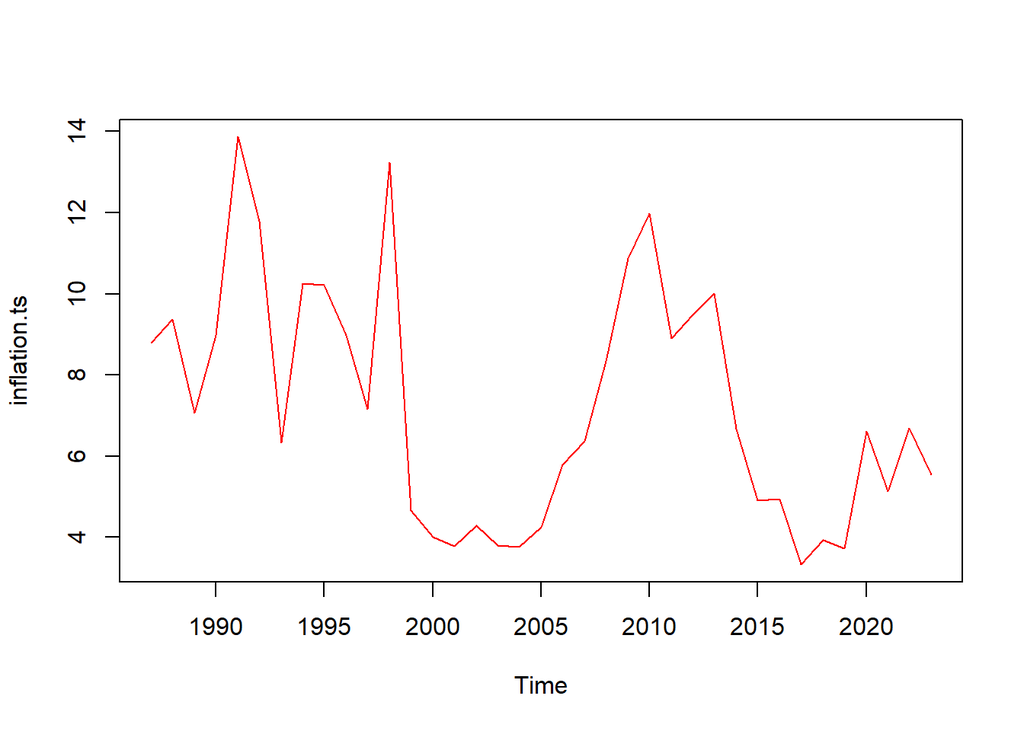

```r
inflation.ts<-ts(d1$Inflation, start=c(1987,1),frequency = 1)
plot(inflation.ts, col = "red")
```

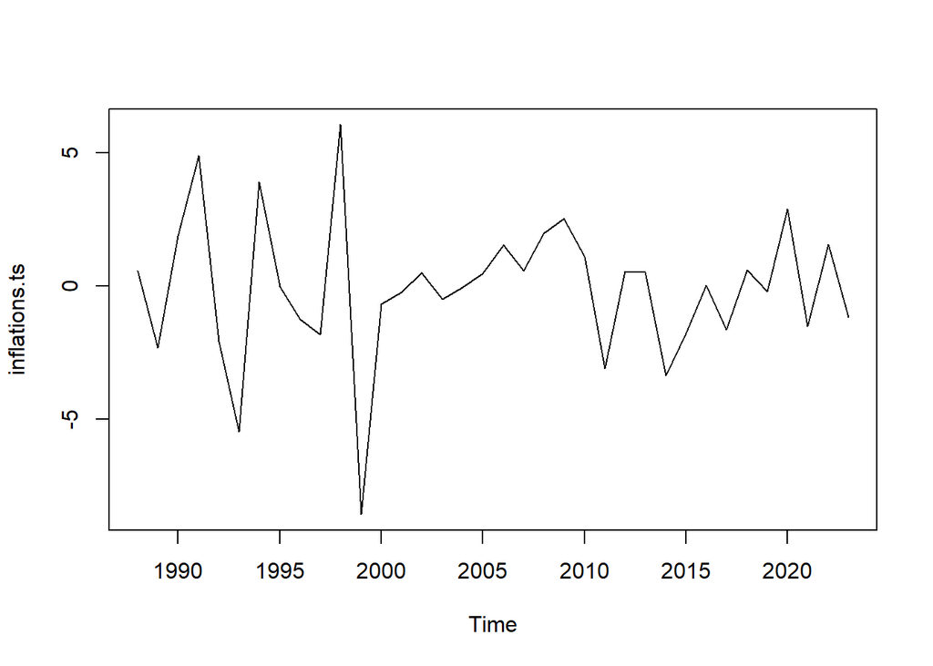

```r
inflations.ts<-diff(inflation.ts)
plot(inflations.ts)
```

```r
PP.test(inflations.ts)
```

```
##
##  Phillips-Perron Unit Root Test
##
## data:  inflations.ts
## Dickey-Fuller = -8.0162, Truncation lag parameter = 3, p-value = 0.01
```

From the Results using Philips pheron test we rejected our null hypothesis and founded that our data for Inflation is stationary

```r
crudeoil.ts<-ts(d1$`Curde Oil Prices`, start=c(1987,1),frequency = 1)
crudeoils.ts<-diff(crudeoil.ts)
pp.test(diff(crudeoil.ts))
```

```
##
##  Phillips-Perron Unit Root Test
##
## data:  diff(crudeoil.ts)
## Dickey-Fuller Z(alpha) = -33.078, Truncation lag parameter = 3, p-value
## = 0.01
## alternative hypothesis: stationary
```

From the Results using Philips perron test we rejected our null hypothesis and founded that our data for crude oil prices is stationary

```r
year<-d1$Date
View(year)
year.ts<-ts(year, start= c(1987,1), frequency = 1)
year.ts<-year[-37]
```

```r
exchangerate.ts<-ts(d1$`Exchange rate`, start=c(1987,1),frequency = 1)
exchangerates.ts<-diff(exchangerate.ts)
exchangerates.ts
```

```
## Time Series:
## Start = 1988
## End = 2023
## Frequency = 1
##  [1]  0.96  2.31  1.27  5.24  3.18  4.57  0.88  1.06  3.00  0.88  4.95  1.80
## [13]  1.88  2.25  1.42 -2.03 -1.26 -1.22  1.21 -3.96  2.16  4.90 -2.68  0.94
## [25]  6.77  3.13  5.76  0.64  3.49  1.33  2.30  0.30  5.99 -1.81  6.78  0.55
```

```r
pp.test(exchangerate.ts)
```

```
##
##  Phillips-Perron Unit Root Test
##
## data:  exchangerate.ts
## Dickey-Fuller Z(alpha) = -6.0844, Truncation lag parameter = 3, p-value
## = 0.7456
## alternative hypothesis: stationary
```

```r
fiscd.ts<-ts(d1$`Fiscal Deficit`, start=c(1987,1), frequency = 1)
fiscd.ts
```

```
## Time Series:
## Start = 1987
## End = 2023
## Frequency = 1
##  [1]   27044   30923   35632   44632   36325   40173   60257   57703   60243
## [10]   66733   88937  113349  104716  118816  140955  145072  123273  125794
## [19]  146435  142573  126912  336992  418482  373591  515990  490190  502858
## [28]  510725  532791  535618  591062  649418  933651 1818291 1584521 1755319
## [37] 1786816
```

```r
fiscds.ts<-diff(fiscd.ts)
```

```r
df1<-data.frame(inflations.ts, crudeoils.ts,exchangerates.ts, fiscds.ts)
crudeoil.ts<-ts(d1$`Curde Oil Prices`, start=c(1987,1),frequency = 1)
library(tidyverse)
```

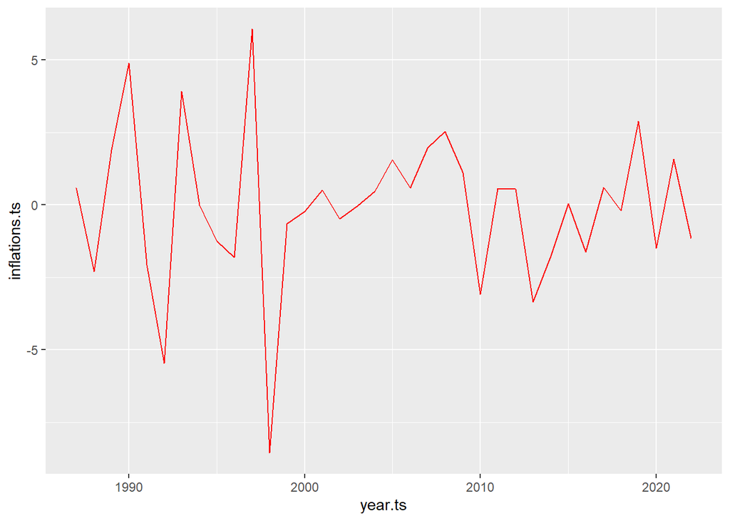

```r
ggplot(df1, aes(year.ts,inflations.ts)) + geom_line(color="red")
```

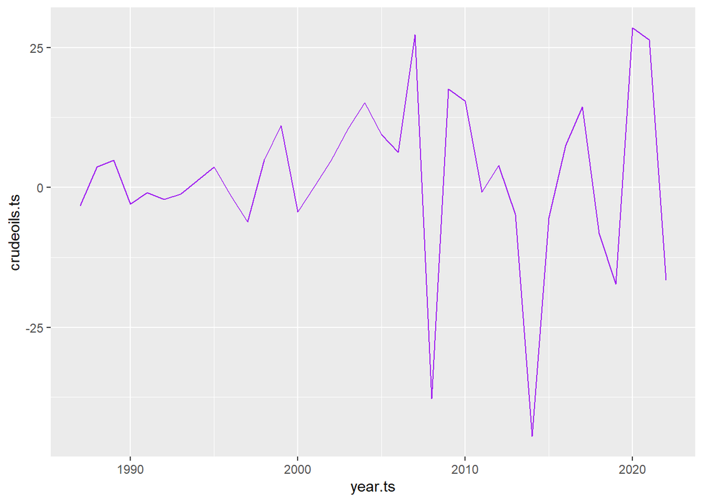

```r
crudeoils.ts<-diff(crudeoil.ts)
ggplot(df1, aes(year.ts,crudeoils.ts)) + geom_line(color="purple")
```

```r
PP.test(exchangerates.ts)
```

```
##
##  Phillips-Perron Unit Root Test
##
## data:  exchangerates.ts
## Dickey-Fuller = -6.4312, Truncation lag parameter = 3, p-value = 0.01
```

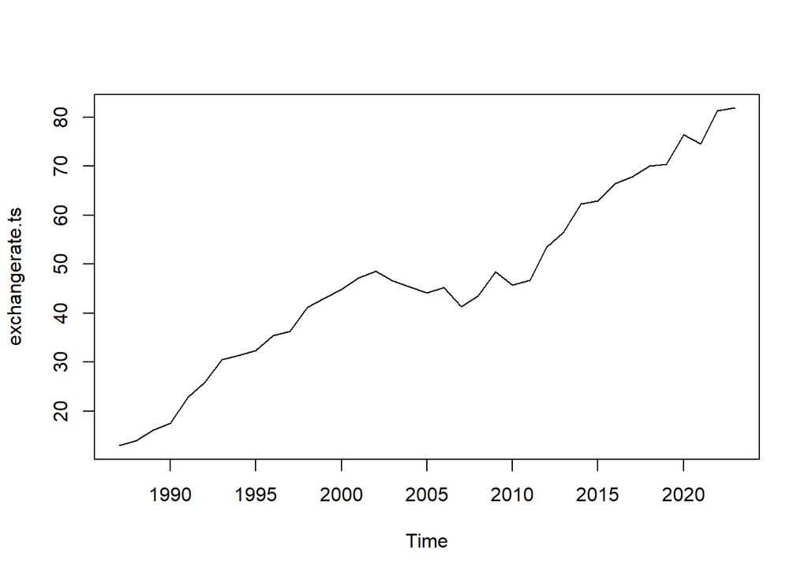

```r
plot(exchangerate.ts)
```

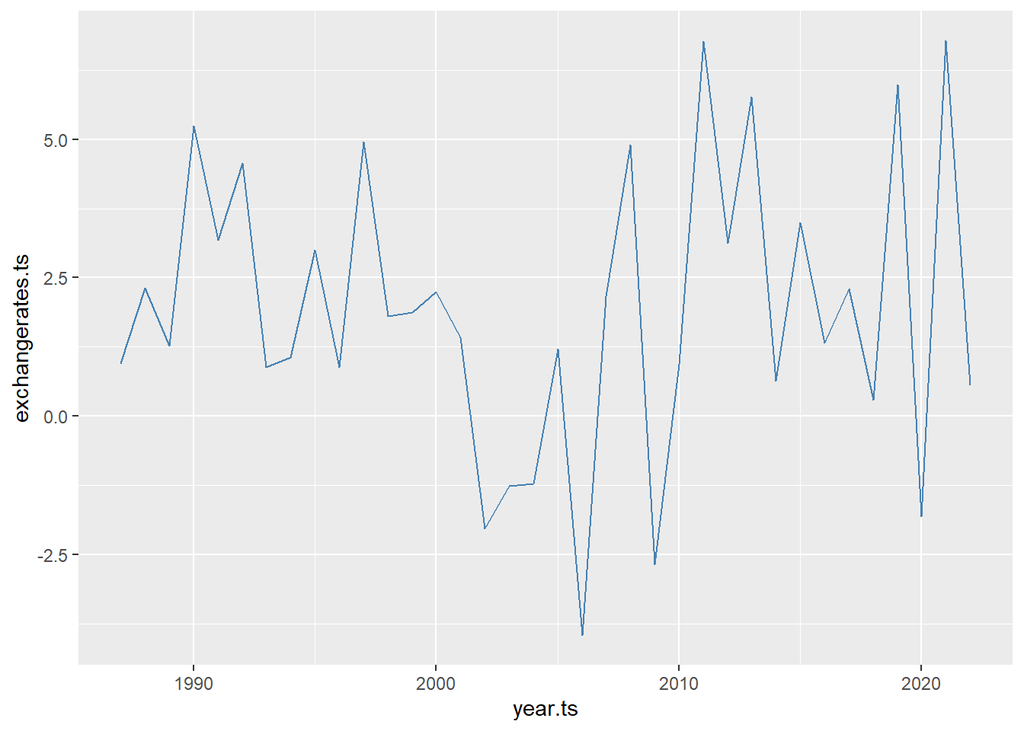

```r
ggplot(df1, aes(year.ts, exchangerates.ts)) + geom_line(color="steelblue")
```

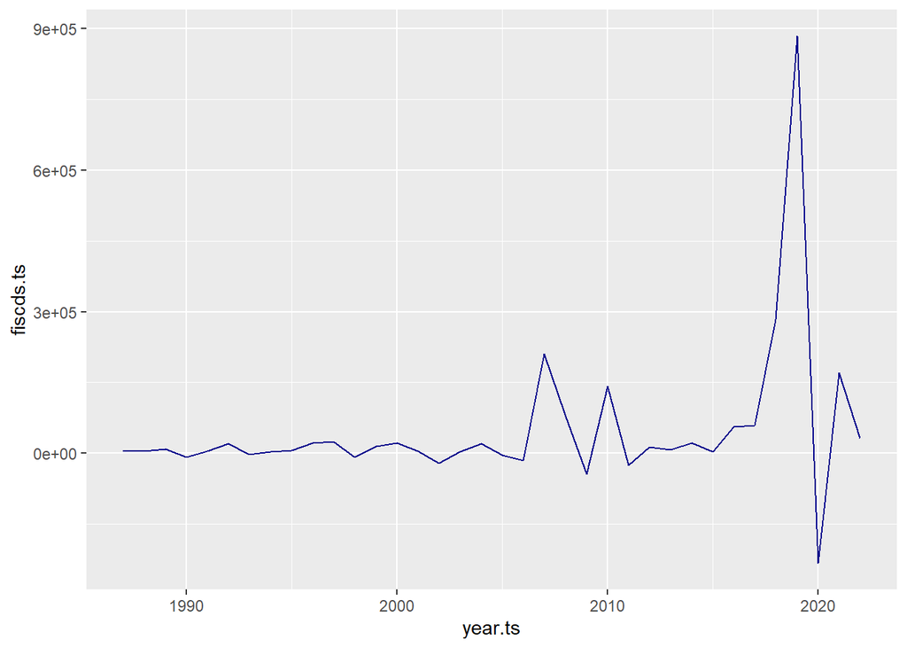

```r
ggplot(df1, aes(year.ts,fiscds.ts)) + geom_line(color="darkblue")
```

```r
pp.test(fiscds.ts)
```

```
##
##  Phillips-Perron Unit Root Test
##
## data:  fiscds.ts
## Dickey-Fuller Z(alpha) = -38.793, Truncation lag parameter = 3, p-value
## = 0.01
## alternative hypothesis: stationary
```

```r
cor.test(inflations.ts,crudeoils.ts)
```

```
##
##  Pearson's product-moment correlation
##
## data:  inflations.ts and crudeoils.ts
## t = -0.30605, df = 34, p-value = 0.7614
## alternative hypothesis: true correlation is not equal to 0
## 95 percent confidence interval:
##  -0.3745017  0.2809589
## sample estimates:
##       cor
## -0.052415
```

```r
cor.test(inflations.ts,exchangerates.ts)
```

```
##
##  Pearson's product-moment correlation
##
## data:  inflations.ts and exchangerates.ts
## t = 0.83394, df = 34, p-value = 0.4101
## alternative hypothesis: true correlation is not equal to 0
## 95 percent confidence interval:
##  -0.1960764  0.4492204
## sample estimates:
##       cor
## 0.1415797
```

```r
cor.test(inflations.ts,fiscds.ts)
```

```
##
##  Pearson's product-moment correlation
##
## data:  inflations.ts and fiscds.ts
## t = 1.2491, df = 34, p-value = 0.2202
## alternative hypothesis: true correlation is not equal to 0
## 95 percent confidence interval:
##  -0.1278738  0.5033584
## sample estimates:
##       cor
## 0.2094616
```

From the Results using Philips perron test we rejected our null hypothesis and founded that our data for Exchange rate is stationary

```r
library(jtools)
lm1<-lm(inflations.ts~crudeoils.ts+exchangerates.ts+fiscds.ts,data=d1)
summary(lm1)
```

```
##
## Call:
## lm(formula = inflations.ts ~ crudeoils.ts + exchangerates.ts +
##     fiscds.ts, data = d1)
##
## Residuals:
##     Min      1Q  Median      3Q     Max
## -8.2931 -1.1948  0.2198  1.0050  5.9925
##
## Coefficients:
##                    Estimate Std. Error t value Pr(>|t|)
## (Intercept)      -3.976e-01  5.905e-01  -0.673    0.506
## crudeoils.ts      1.520e-03  3.247e-02   0.047    0.963
## exchangerates.ts  8.233e-02  1.937e-01   0.425    0.674
## fiscds.ts         3.010e-06  3.047e-06   0.988    0.331
##
## Residual standard error: 2.751 on 32 degrees of freedom
## Multiple R-squared:  0.04929,    Adjusted R-squared:  -0.03984
## F-statistic: 0.553 on 3 and 32 DF,  p-value: 0.6498
```

The linear regression model for inflations.ts:

inflations.ts = −0.3976 + 0.00152 × crudeoils.ts + 0.08233 × exchangerates.ts + 3.01×10 − 6 × fiscds.ts

```r
resd1<-residuals(lm1)
pp.test(resd1)
```

```
##
##  Phillips-Perron Unit Root Test
##
## data:  resd1
## Dickey-Fuller Z(alpha) = -39.835, Truncation lag parameter = 3, p-value
## = 0.01
## alternative hypothesis: stationary
```

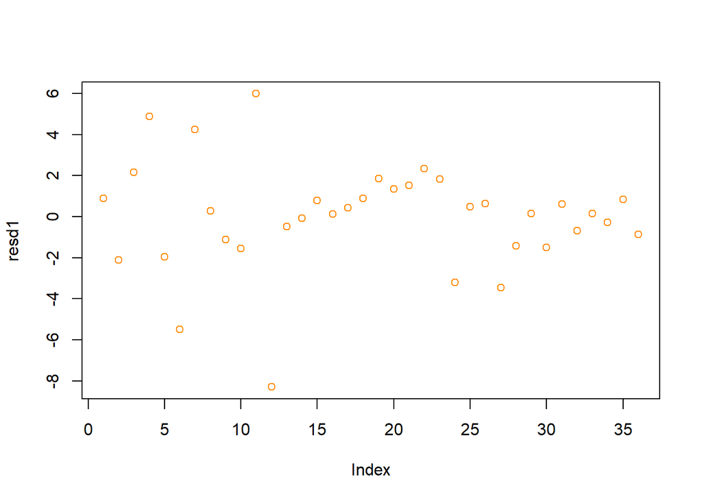

```r
plot(resd1, col= "darkorange")
```

```r
mean(resd1)
```

```
## [1] -7.258131e-19
```

Using Philips perron test we found that residuals of inflation with exchange rates, crude oil prices, exchange rates and gross fiscal deficit follows a stationary process

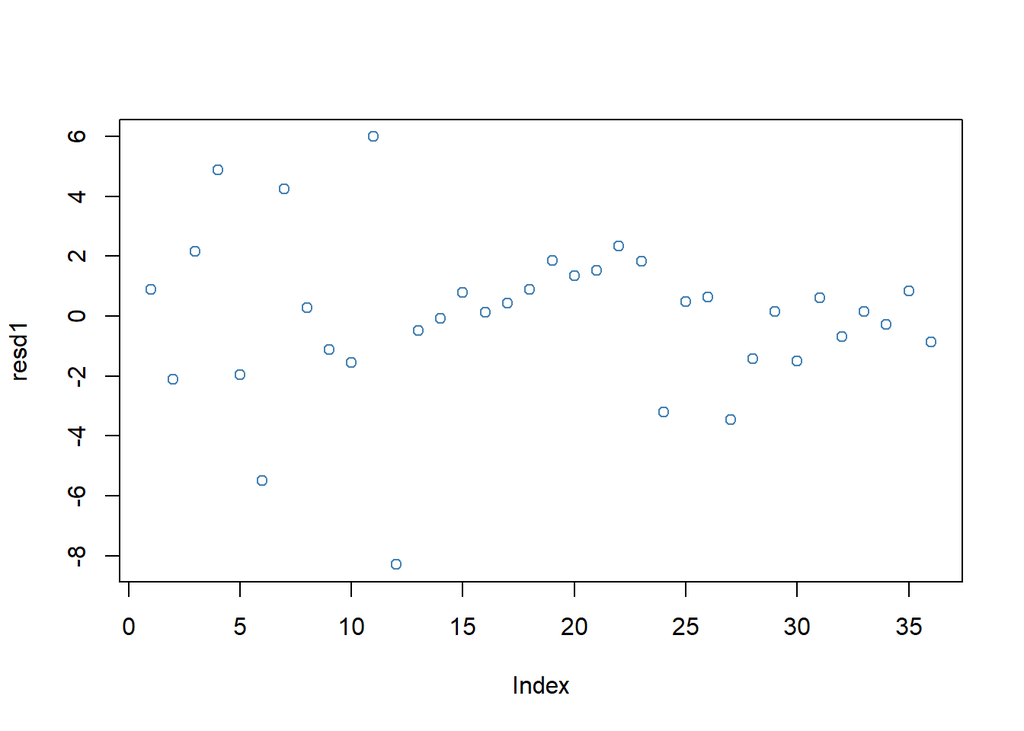

```r
plot(resd1, col ="steelblue")
```

```r
library(tsDyn)
library(aTSA)
coint.test(inflations.ts,crudeoils.ts,d=1)
```

```
## Response: diff(inflations.ts,1)
## Input: diff(crudeoils.ts,1)
## Number of inputs: 1
## Model: y ~ X - 1
## -------------------------------
## Engle-Granger Cointegration Test
## alternative: cointegrated
##
## Type 1: no trend
##     lag      EG p.value
##    3.00   -8.82    0.01
## -----
##  Type 2: linear trend
##     lag      EG p.value
##   3.000   0.153   0.100
## -----
##  Type 3: quadratic trend
##     lag      EG p.value
##   3.000  -0.329   0.100
## -----------
## Note: p.value = 0.01 means p.value <= 0.01
##     : p.value = 0.10 means p.value >= 0.10
```

```r
lm2<-lm(inflations.ts~exchangerates.ts,data=d1)
summary(lm2)
```

```
##
## Call:
## lm(formula = inflations.ts ~ exchangerates.ts, data = d1)
##
## Residuals:
##     Min      1Q  Median      3Q     Max
## -8.4539 -1.3480  0.1837  1.5795  5.7135
##
## Coefficients:
##                  Estimate Std. Error t value Pr(>|t|)
## (Intercept)       -0.3700     0.5626  -0.658    0.515
## exchangerates.ts   0.1461     0.1751   0.834    0.410
##
## Residual standard error: 2.71 on 34 degrees of freedom
## Multiple R-squared:  0.02004,    Adjusted R-squared:  -0.008777
## F-statistic: 0.6955 on 1 and 34 DF,  p-value: 0.4101
```

The linear regression model fitted is expressed as:

inflations.ts = −0.3700 + 0.1461 × exchangerates.ts For each one-unit increase in exchange rates, the model predicts an increase of 0.1461 units in inflations.ts, assuming other variables remain constant.

```r
resd2<-residuals(lm2)
mean(resd2)
```

```
## [1] -8.015115e-17
```

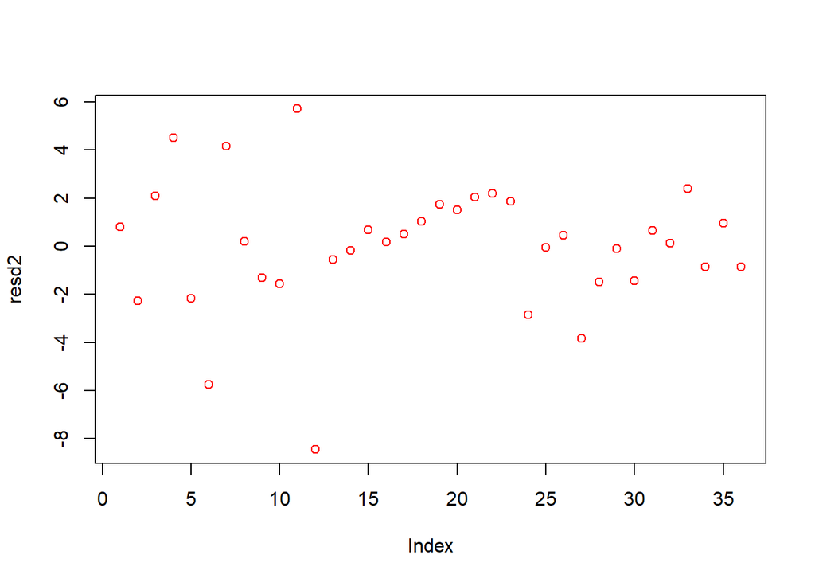

```r
plot(resd2, col="red")
```

```r
library(tseries)
library(urca)
pp.test(resd2)
```

```
## Phillips-Perron Unit Root Test
## alternative: stationary
##
## Type 1: no drift no trend
##  lag Z_rho p.value
##    3   -40    0.01
## -----
##  Type 2: with drift no trend
##  lag Z_rho p.value
##    3   -40    0.01
## -----
##  Type 3: with drift and trend
##  lag Z_rho p.value
##    3   -40    0.01
## ---------------
## Note: p-value = 0.01 means p.value <= 0.01
```

```r
coint.test(inflations.ts,exchangerates.ts)
```

```
## Response: inflations.ts
## Input: exchangerates.ts
## Number of inputs: 1
## Model: y ~ X + 1
## -------------------------------
## Engle-Granger Cointegration Test
## alternative: cointegrated
##
## Type 1: no trend
##     lag      EG p.value
##  3.0000 -3.5783  0.0128
## -----
##  Type 2: linear trend
##     lag      EG p.value
##  3.0000 -0.0129  0.1000
## -----
##  Type 3: quadratic trend
##     lag      EG p.value
##  3.0000  0.0544  0.1000
## -----------
## Note: p.value = 0.01 means p.value <= 0.01
##     : p.value = 0.10 means p.value >= 0.10
```

```r
lm3<-lm(inflations.ts~fiscds.ts)
summary(lm3)
```

```
##
## Call:
## lm(formula = inflations.ts ~ fiscds.ts)
##
## Residuals:
##     Min      1Q  Median      3Q     Max
## -8.2731 -1.1469  0.2188  0.9953  6.2409
##
## Coefficients:
##               Estimate Std. Error t value Pr(>|t|)
## (Intercept) -2.583e-01  4.660e-01  -0.554    0.583
## fiscds.ts    3.436e-06  2.751e-06   1.249    0.220
##
## Residual standard error: 2.677 on 34 degrees of freedom
## Multiple R-squared:  0.04387,    Adjusted R-squared:  0.01575
## F-statistic:  1.56 on 1 and 34 DF,  p-value: 0.2202
```

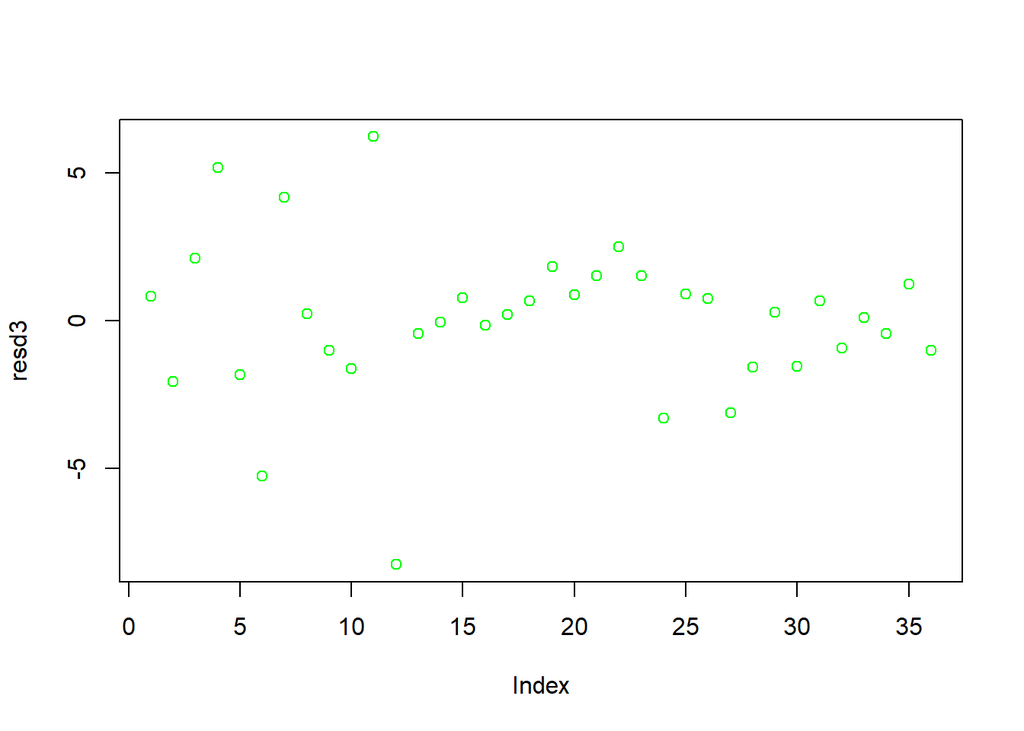

```r
resd3<-residuals(lm3)
plot(resd3, col= "green")
```

```r
pp.test(resd3)
```

```
## Phillips-Perron Unit Root Test
## alternative: stationary
##
## Type 1: no drift no trend
##  lag Z_rho p.value
##    3 -39.9    0.01
## -----
##  Type 2: with drift no trend
##  lag Z_rho p.value
##    3 -39.9    0.01
## -----
##  Type 3: with drift and trend
##  lag Z_rho p.value
##    3 -39.8    0.01
## ---------------
## Note: p-value = 0.01 means p.value <= 0.01
```

Using philips perron test we found out that the residuals of inflation and gross fiscal deficit follows a stationary process

```r
lm4<-lm(inflations.ts~crudeoils.ts,data=d1)
summary(lm4)
```

```
##
## Call:
## lm(formula = inflations.ts ~ crudeoils.ts, data = d1)
##
## Residuals:
##     Min      1Q  Median      3Q     Max
## -8.4395 -1.2918  0.1001  1.4390  6.0830
##
## Coefficients:
##               Estimate Std. Error t value Pr(>|t|)
## (Intercept)  -0.074918   0.458390  -0.163    0.871
## crudeoils.ts -0.009439   0.030840  -0.306    0.761
##
## Residual standard error: 2.734 on 34 degrees of freedom
## Multiple R-squared:  0.002747,   Adjusted R-squared:  -0.02658
## F-statistic: 0.09367 on 1 and 34 DF,  p-value: 0.7614
```

```r
coint.test(inflations.ts,fiscds.ts)
```

```
## Response: inflations.ts
## Input: fiscds.ts
## Number of inputs: 1
## Model: y ~ X + 1
## -------------------------------
## Engle-Granger Cointegration Test
## alternative: cointegrated
##
## Type 1: no trend
##     lag      EG p.value
##    3.00   -4.13    0.01
## -----
##  Type 2: linear trend
##     lag      EG p.value
##   3.000  -0.325   0.100
## -----
##  Type 3: quadratic trend
##     lag      EG p.value
##   3.000   0.413   0.100
## -----------
## Note: p.value = 0.01 means p.value <= 0.01
##     : p.value = 0.10 means p.value >= 0.10
```

On performing the Engle-Granger cointegration test on the inflation and Fiscal deficit we found that there exists a long term relation between them following no trend Outputs P value- 0.01 ,0.01<0.05

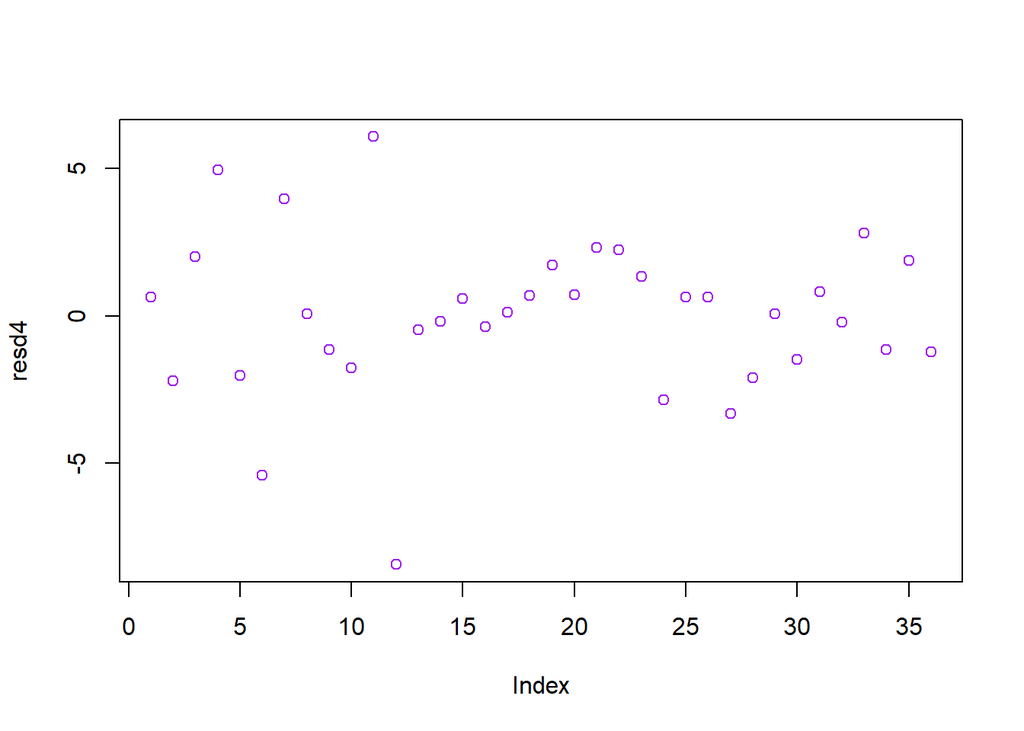

```r
resd4<-residuals(lm4)
plot(resd4, col= "purple")
```

```r
library(vars)
vardata<-data.frame(inflations.ts,crudeoils.ts,exchangerates.ts,fiscds.ts)
vardata
```

```
##    inflations.ts crudeoils.ts exchangerates.ts fiscds.ts
## 1         0.5824        -3.23             0.96      3879
## 2        -2.3092         3.67             2.31      4709
## 3         1.8969         4.89             1.27      9000
## 4         4.8990        -2.99             5.24     -8307
## 5        -2.0824        -0.96             3.18      3848
## 6        -5.4609        -2.15             4.57     20084
## 7         3.9210        -1.23             0.88     -2554
## 8        -0.0230         1.23             1.06      2540
## 9        -1.2477         3.69             3.00      6490
## 10       -1.8129        -1.51             0.88     22204
## 11        6.0665        -6.19             4.95     24412
## 12       -8.5610         4.93             1.80     -8633
## 13       -0.6604        11.03             1.88     14100
## 14       -0.2301        -4.40             2.25     22139
```

[output cut: 22 more lines]

```r
View(vardata)
varlags<-VARselect(vardata, lag.max = 5)
varlags
```

```
## $selection
## AIC(n)  HQ(n)  SC(n) FPE(n)
##      5      5      1      5
##
## $criteria
##                   1            2            3            4            5
## AIC(n) 3.379759e+01 3.379034e+01 3.408381e+01 3.422646e+01 3.135415e+01
## HQ(n)  3.409917e+01 3.433318e+01 3.486791e+01 3.525183e+01 3.262078e+01
## SC(n)  3.472274e+01 3.545562e+01 3.648920e+01 3.737198e+01 3.523980e+01
## FPE(n) 4.819955e+14 5.067849e+14 7.909359e+14 1.257550e+15 1.340767e+14
```

Model with the lowest Information Criteria: Selected Model Order of model (n): 5 Selected Model Order by AIC: 5 Selected Model Order by HQ: 5 Selected Model Order by SC: 1 Selected Model Order by FPE: 5

```r
varmodel<-VAR(vardata,p=2,type = "both")
varmodel
```

```
##
## VAR Estimation Results:
## =======================
##
## Estimated coefficients for equation inflations.ts:
## ==================================================
## Call:
## inflations.ts = inflations.ts.l1 + crudeoils.ts.l1 + exchangerates.ts.l1 + fiscds.ts.l1 + inflations.ts.l2 + crudeoils.ts.l2 + exchangerates.ts.l2 + fiscds.ts.l2 + const + trend
##
##    inflations.ts.l1     crudeoils.ts.l1 exchangerates.ts.l1        fiscds.ts.l1
##       -4.571609e-01       -9.935450e-03       -4.277179e-01        2.469394e-06
##    inflations.ts.l2     crudeoils.ts.l2 exchangerates.ts.l2        fiscds.ts.l2
##       -3.588196e-01        6.754171e-02       -2.336430e-01        5.339655e-06
##               const               trend
##        1.550521e+00       -4.321548e-02
##
##
## Estimated coefficients for equation crudeoils.ts:
## =================================================
## Call:
## crudeoils.ts = inflations.ts.l1 + crudeoils.ts.l1 + exchangerates.ts.l1 + fiscds.ts.l1 + inflations.ts.l2 + crudeoils.ts.l2 + exchangerates.ts.l2 + fiscds.ts.l2 + const + trend
##
##    inflations.ts.l1     crudeoils.ts.l1 exchangerates.ts.l1        fiscds.ts.l1
##        6.527370e-01       -2.129308e-01       -2.137029e+00        1.119189e-05
##    inflations.ts.l2     crudeoils.ts.l2 exchangerates.ts.l2        fiscds.ts.l2
##        6.085265e-01       -1.548137e-01       -5.991802e-01        3.731700e-05
##               const               trend
##        1.016578e+01       -2.345192e-01
##
##
## Estimated coefficients for equation exchangerates.ts:
## =====================================================
## Call:
## exchangerates.ts = inflations.ts.l1 + crudeoils.ts.l1 + exchangerates.ts.l1 + fiscds.ts.l1 + inflations.ts.l2 + crudeoils.ts.l2 + exchangerates.ts.l2 + fiscds.ts.l2 + const + trend
##
##    inflations.ts.l1     crudeoils.ts.l1 exchangerates.ts.l1        fiscds.ts.l1
##       -7.308059e-02        5.867223e-02       -2.165147e-02        7.243998e-07
##    inflations.ts.l2     crudeoils.ts.l2 exchangerates.ts.l2        fiscds.ts.l2
##       -9.926717e-03        2.385144e-02        3.969590e-01        9.818323e-07
##               const               trend
##        1.076212e+00       -4.081662e-03
##
##
## Estimated coefficients for equation fiscds.ts:
## ==============================================
## Call:
## fiscds.ts = inflations.ts.l1 + crudeoils.ts.l1 + exchangerates.ts.l1 + fiscds.ts.l1 + inflations.ts.l2 + crudeoils.ts.l2 + exchangerates.ts.l2 + fiscds.ts.l2 + const + trend
##
##    inflations.ts.l1     crudeoils.ts.l1 exchangerates.ts.l1        fiscds.ts.l1
##        2.800931e+03        9.325737e+02       -2.164200e+04       -6.852355e-03
##    inflations.ts.l2     crudeoils.ts.l2 exchangerates.ts.l2        fiscds.ts.l2
##        3.237466e+03        2.569374e+03        1.576614e+04       -1.202011e-01
##               const               trend
##       -5.285460e+04        6.116967e+03
```

```r
summary(varmodel)
```

```
##
## VAR Estimation Results:
## =========================
## Endogenous variables: inflations.ts, crudeoils.ts, exchangerates.ts, fiscds.ts
## Deterministic variables: both
## Sample size: 34
## Log Likelihood: -726.259
## Roots of the characteristic polynomial:
## 0.6976 0.6976 0.6436 0.6301 0.6301 0.5594 0.5594 0.4438
## Call:
## VAR(y = vardata, p = 2, type = "both")
##
##
## Estimation results for equation inflations.ts:
## ==============================================
## inflations.ts = inflations.ts.l1 + crudeoils.ts.l1 + exchangerates.ts.l1 + fiscds.ts.l1 + inflations.ts.l2 + crudeoils.ts.l2 + exchangerates.ts.l2 + fiscds.ts.l2 + const + trend
##
##                       Estimate Std. Error t value Pr(>|t|)
## inflations.ts.l1    -4.572e-01  1.645e-01  -2.780   0.0104 *
## crudeoils.ts.l1     -9.935e-03  3.325e-02  -0.299   0.7676
## exchangerates.ts.l1 -4.277e-01  1.733e-01  -2.468   0.0211 *
## fiscds.ts.l1         2.469e-06  3.073e-06   0.803   0.4296
## inflations.ts.l2    -3.588e-01  1.604e-01  -2.237   0.0348 *
## crudeoils.ts.l2      6.754e-02  3.249e-02   2.079   0.0485 *
## exchangerates.ts.l2 -2.336e-01  2.266e-01  -1.031   0.3127
## fiscds.ts.l2         5.340e-06  2.882e-06   1.853   0.0762 .
## const                1.551e+00  1.083e+00   1.431   0.1653
## trend               -4.322e-02  4.686e-02  -0.922   0.3656
## ---
## Signif. codes:  0 '***' 0.001 '**' 0.01 '*' 0.05 '.' 0.1 ' ' 1
##
##
## Residual standard error: 2.349 on 24 degrees of freedom
## Multiple R-Squared: 0.4691,  Adjusted R-squared:  0.27
## F-statistic: 2.356 on 9 and 24 DF,  p-value: 0.04536
##
##
## Estimation results for equation crudeoils.ts:
## =============================================
## crudeoils.ts = inflations.ts.l1 + crudeoils.ts.l1 + exchangerates.ts.l1 + fiscds.ts.l1 + inflations.ts.l2 + crudeoils.ts.l2 + exchangerates.ts.l2 + fiscds.ts.l2 + const + trend
```

[output cut: 66 more lines]

```
##
##
## Covariance matrix of residuals:
##                  inflations.ts crudeoils.ts exchangerates.ts  fiscds.ts
## inflations.ts            5.516   -6.205e+00             1.10  7.609e+04
## crudeoils.ts            -6.205    1.995e+02           -16.12 -9.740e+05
## exchangerates.ts         1.100   -1.612e+01             8.25  1.604e+05
## fiscds.ts            76092.189   -9.740e+05        160353.61  2.917e+10
##
## Correlation matrix of residuals:
##                  inflations.ts crudeoils.ts exchangerates.ts fiscds.ts
## inflations.ts           1.0000      -0.1870           0.1630    0.1897
## crudeoils.ts           -0.1870       1.0000          -0.3974   -0.4037
## exchangerates.ts        0.1630      -0.3974           1.0000    0.3269
## fiscds.ts               0.1897      -0.4037           0.3269    1.0000
```

Equation for inflations.ts:

inflations.ts=−0.4572 × inflations.ts.l1 − 0.0099 × crudeoils.ts.l1 − 0.4277 × exchangerates.ts.l1 + 0.00000247 × fiscds.ts.l1 − 0.3588 × inflations.ts.l2 + 0.0675 × crudeoils.ts.l2 − 0.2336 × exchangerates.ts.l2 + 0.00000534 × fiscds.ts.l2 + 1.5505 × const − 0.0432 × trend

```r
vpredict=predict(varmodel,n.ahead=10,ci=0.90)
vpredict
```

```
## $inflations.ts
##             fcst     lower    upper       CI
##  [1,]  1.0304037 -2.832698 4.893506 3.863102
##  [2,] -2.0190789 -6.714674 2.676516 4.695595
##  [3,]  1.1173748 -3.782144 6.016893 4.899519
##  [4,] -0.6806541 -5.820107 4.458799 5.139453
##  [5,]  0.1399418 -5.049136 5.329020 5.189078
##  [6,] -0.5226062 -5.826647 4.781434 5.304041
##  [7,]  0.1523777 -5.185527 5.490283 5.337905
##  [8,] -0.2991776 -5.643089 5.044734 5.343911
##  [9,] -0.1205579 -5.469568 5.228452 5.349010
## [10,] -0.2102829 -5.561679 5.141113 5.351396
##
## $crudeoils.ts
##              fcst     lower    upper       CI
```

[output cut: 36 more lines]

Here we predicted the values of Inflation as 6.58% (5.55%+1.03%), Exchange rate as 85.21 (81.90 + 3.31) for the year 2024 followed by the results of other variables and other years

```r
grangertest(inflations.ts~exchangerates.ts, order=4)
```

```
## Granger causality test
##
## Model 1: inflations.ts ~ Lags(inflations.ts, 1:4) + Lags(exchangerates.ts, 1:4)
## Model 2: inflations.ts ~ Lags(inflations.ts, 1:4)
##   Res.Df Df      F  Pr(>F)
## 1     23
## 2     27 -4 2.9525 0.04175 *
## ---
## Signif. codes:  0 '***' 0.001 '**' 0.01 '*' 0.05 '.' 0.1 ' ' 1
```

```r
grangertest(inflations.ts~crudeoils.ts, order =4)
```

```
## Granger causality test
##
## Model 1: inflations.ts ~ Lags(inflations.ts, 1:4) + Lags(crudeoils.ts, 1:4)
## Model 2: inflations.ts ~ Lags(inflations.ts, 1:4)
##   Res.Df Df      F Pr(>F)
## 1     23
## 2     27 -4 0.7189 0.5877
```

Granger causality test results,It cannot be concluded that lagged values of crude oil prices Granger-cause changes in inflation, at least within the specified lag range (1 to 4 lags). The additional lagged values of crude oil prices do not provide a statistically significant improvement in predicting inflation compared to a model that only includes lagged values of inflation.

```r
grangertest(inflations.ts~fiscds.ts, order =4)
```

```
## Granger causality test
##
## Model 1: inflations.ts ~ Lags(inflations.ts, 1:4) + Lags(fiscds.ts, 1:4)
## Model 2: inflations.ts ~ Lags(inflations.ts, 1:4)
##   Res.Df Df      F Pr(>F)
## 1     23
## 2     27 -4 0.3512 0.8405
```